# Tidy Tuesday: Global Health Spending

Author

Alexandra Tejada-Strop

Published

April 21, 2026

This analysis uses the WHO Global Health Expenditure Database (GHED), which includes data on health spending for 195 countries from 2000 to 2023. The dataset shows how much countries spend on health care and where that funding comes from, including government spending, private sources, and external aid.

The main question guiding this analysis is:

Can we predict a country’s out-of-pocket payment burden (as a percentage of total health spending) based on the share of funding from government, private, and external sources?

This question matters for public health because high out-of-pocket costs can make it harder for people to access care and may lead to financial strain. This is especially true in low- and middle-income countries (World Health Organization, 2024), where individuals often bear a larger share of health care costs.

## AI Use

Some portions of this analysis were completed with AI assistance (Claude, Anthropic). Specifically, AI was used to help troubleshoot coding errors and debug issues that came up during the modeling workflow.

All analytical decisions, interpretations, and written content reflect my own work and understanding of the data.

## Setup

```r
# Load all necessary packages
library(tidyverse)   # data wrangling and visualization
library(tidymodels)  # modeling framework
library(ggplot2)     # plotting
library(knitr)       # tables
library(corrplot)    # correlation plots
library(vip)         # variable importance plots
```

## Data Loading

```r
# Load the three datasets directly from GitHub
financing_schemes <- readr::read_csv('https://raw.githubusercontent.com/rfordatascience/tidytuesday/main/data/2026/2026-04-21/financing_schemes.csv')

health_spending <- readr::read_csv('https://raw.githubusercontent.com/rfordatascience/tidytuesday/main/data/2026/2026-04-21/health_spending.csv')

spending_purpose <- readr::read_csv('https://raw.githubusercontent.com/rfordatascience/tidytuesday/main/data/2026/2026-04-21/spending_purpose.csv')

# Quick check of each dataset
glimpse(financing_schemes)
```

```
Rows: 33,240
Columns: 7
$ country_name     <chr> "Afghanistan", "Afghanistan", "Afghanistan", "Afghani…
$ iso3_code        <chr> "AFG", "AFG", "AFG", "AFG", "AFG", "AFG", "AFG", "AFG…
$ year             <dbl> 2002, 2002, 2002, 2002, 2002, 2002, 2002, 2002, 2003,…
$ indicator_code   <chr> "hf1_che", "hf1_usd2023", "hf2_che", "hf2_usd2023", "…
$ financing_scheme <chr> "Government schemes and compulsory contributory healt…
$ value            <dbl> 8.914237e-01, 5.906209e+06, 1.373297e+01, 9.098904e+0…
$ unit             <chr> "% of current health expenditure", "constant 2023 US$…
```

```r
glimpse(health_spending)
```

```
Rows: 30,898
Columns: 7
$ country_name     <chr> "Afghanistan", "Afghanistan", "Afghanistan", "Afghani…
$ iso3_code        <chr> "AFG", "AFG", "AFG", "AFG", "AFG", "AFG", "AFG", "AFG…
$ year             <dbl> 2002, 2002, 2002, 2002, 2002, 2002, 2002, 2003, 2003,…
$ indicator_code   <chr> "che_usd2023", "ext_che", "ext_usd2023", "gghed_che",…
$ expenditure_type <chr> "Current Health Expenditure (CHE)", "External Health …
$ value            <dbl> 6.625590e+08, 1.373297e+01, 9.098904e+07, 8.914238e-0…
$ unit             <chr> "constant 2023 US$", "% of current health expenditure…
```

```r
glimpse(spending_purpose)
```

```
Rows: 11,736
Columns: 7
$ country_name     <chr> "Afghanistan", "Afghanistan", "Afghanistan", "Afghani…
$ iso3_code        <chr> "AFG", "AFG", "AFG", "AFG", "AFG", "AFG", "AFG", "AFG…
$ year             <dbl> 2016, 2016, 2016, 2016, 2016, 2016, 2016, 2016, 2016,…
$ indicator_code   <chr> "hc1_che", "hc1_usd2023", "hc3_che", "hc3_usd2023", "…
$ spending_purpose <chr> "Curative care", "Curative care", "Long-term care (he…
$ value            <dbl> 2.045054e+01, 4.572967e+08, 6.288820e-02, 1.406250e+0…
$ unit             <chr> "% of current health expenditure", "constant 2023 US$…
```

Data were retrieved from the TidyTuesday repository (Data Science Learning Community, 2024).

## Data Wrangling

```r
oop <- financing_schemes %>%
  filter(indicator_code == "hf3_che") %>%
  select(iso3_code, country_name, year, oop_pct = value)


predictors <- health_spending %>%
  filter(indicator_code %in% c("gghed_che", "pvtd_che", "ext_che")) %>%
  select(iso3_code, year, indicator_code, value) %>%
  pivot_wider(names_from = indicator_code, values_from = value) %>%
  rename(
    govt_pct = gghed_che,
    private_pct = pvtd_che,
    external_pct = ext_che
  )

# Join outcome with predictors by country and year
model_data <- oop %>%
  inner_join(predictors, by = c("iso3_code", "year")) %>%
  drop_na()

# Dataset
glimpse(model_data)
```

```
Rows: 4,027
Columns: 7
$ iso3_code    <chr> "AFG", "AFG", "AFG", "AFG", "AFG", "AFG", "AFG", "AFG", "…
$ country_name <chr> "Afghanistan", "Afghanistan", "Afghanistan", "Afghanistan…
$ year         <dbl> 2002, 2003, 2004, 2005, 2006, 2007, 2008, 2009, 2010, 201…
$ oop_pct      <dbl> 85.37561, 86.06919, 84.52759, 78.97009, 76.82498, 78.1699…
$ external_pct <dbl> 13.732970, 6.650364, 9.937138, 15.710566, 18.488485, 16.1…
$ govt_pct     <dbl> 0.8914238, 7.2804446, 5.5352716, 5.3193479, 4.6865387, 5.…
$ private_pct  <dbl> 85.37560, 86.06919, 84.52759, 78.97009, 76.82497, 78.1699…
```

```r
summary(model_data)
```

```
  iso3_code         country_name            year         oop_pct
 Length:4027        Length:4027        Min.   :2000   Min.   : 0.04459
 Class :character   Class :character   1st Qu.:2006   1st Qu.:18.50303
 Mode  :character   Mode  :character   Median :2012   Median :33.14392
                                       Mean   :2012   Mean   :34.82537
                                       3rd Qu.:2018   3rd Qu.:49.44752
                                       Max.   :2023   Max.   :87.90394
  external_pct        govt_pct       private_pct
 Min.   : 0.0000   Min.   : 0.786   Min.   : 0.06145
 1st Qu.: 0.1397   1st Qu.:31.205   1st Qu.:27.34791
 Median : 2.4197   Median :47.804   Median :41.80509
 Mean   :10.2507   Mean   :47.997   Mean   :41.75229
 3rd Qu.:14.9890   3rd Qu.:65.735   3rd Qu.:56.94630
 Max.   :81.5805   Max.   :99.877   Max.   :89.16981
```

```r
# Number of countries and years
cat("Number of countries:", n_distinct(model_data$iso3_code), "\n")
```

```
Number of countries: 183
```

```r
cat("Years covered:", min(model_data$year), "to", max(model_data$year), "\n")
```

```
Years covered: 2000 to 2023
```

```r
cat("Total observations:", nrow(model_data), "\n")
```

```
Total observations: 4027
```

## Exploratory Data Analysis

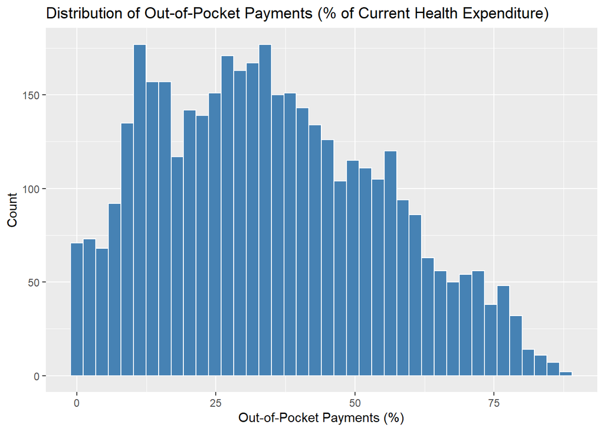

```r
# Distribution of our outcome variable (out-of-pocket payments %)
ggplot(model_data, aes(x = oop_pct)) +
  geom_histogram(bins = 40, fill = "steelblue", color = "white") +
  labs(
    title = "Distribution of Out-of-Pocket Payments (% of Current Health Expenditure)",
    x = "Out-of-Pocket Payments (%)",
    y = "Count"
  )
```

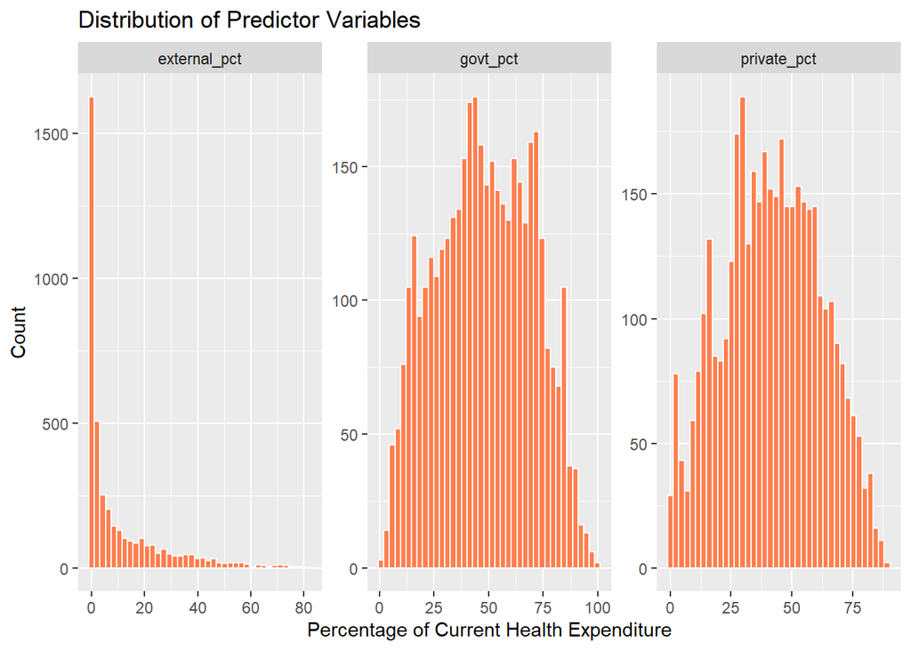

```r
# Distribution of each predictor
model_data %>%
  select(govt_pct, private_pct, external_pct) %>%
  pivot_longer(everything(), names_to = "predictor", values_to = "value") %>%
  ggplot(aes(x = value)) +
  geom_histogram(bins = 40, fill = "coral", color = "white") +
  facet_wrap(~ predictor, scales = "free") +
  labs(
    title = "Distribution of Predictor Variables",
    x = "Percentage of Current Health Expenditure",
    y = "Count"
  )
```

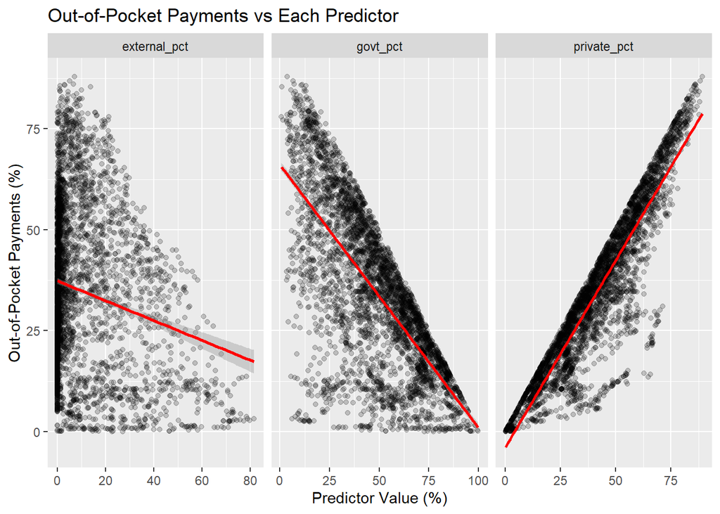

```r
# Scatterplots of each predictor vs outcome
model_data %>%
  select(oop_pct, govt_pct, private_pct, external_pct) %>%
  pivot_longer(-oop_pct, names_to = "predictor", values_to = "value") %>%
  ggplot(aes(x = value, y = oop_pct)) +
  geom_point(alpha = 0.2) +
  geom_smooth(method = "lm", color = "red") +
  facet_wrap(~ predictor, scales = "free_x") +
  labs(
    title = "Out-of-Pocket Payments vs Each Predictor",
    x = "Predictor Value (%)",
    y = "Out-of-Pocket Payments (%)"
  )
```

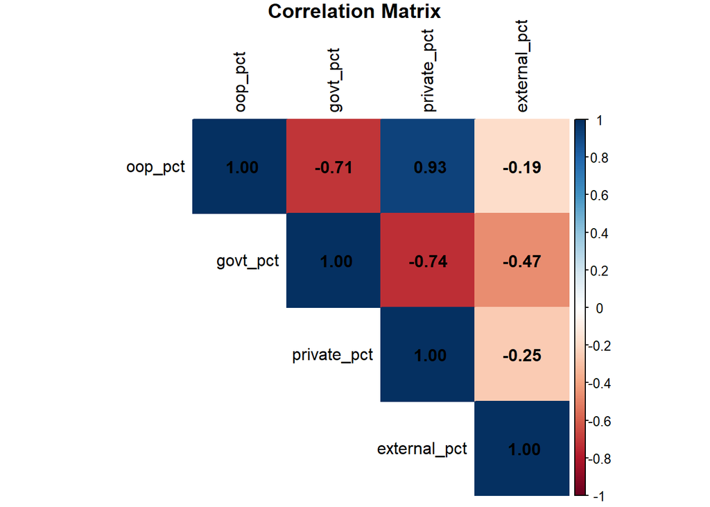

```r
# Correlation
cor_matrix <- model_data %>%
  select(oop_pct, govt_pct, private_pct, external_pct) %>%
  cor(use = "complete.obs")

corrplot(cor_matrix, method = "color", type = "upper",
         addCoef.col = "black", tl.col = "black",
         title = "Correlation Matrix", mar = c(0,0,1,0))
```

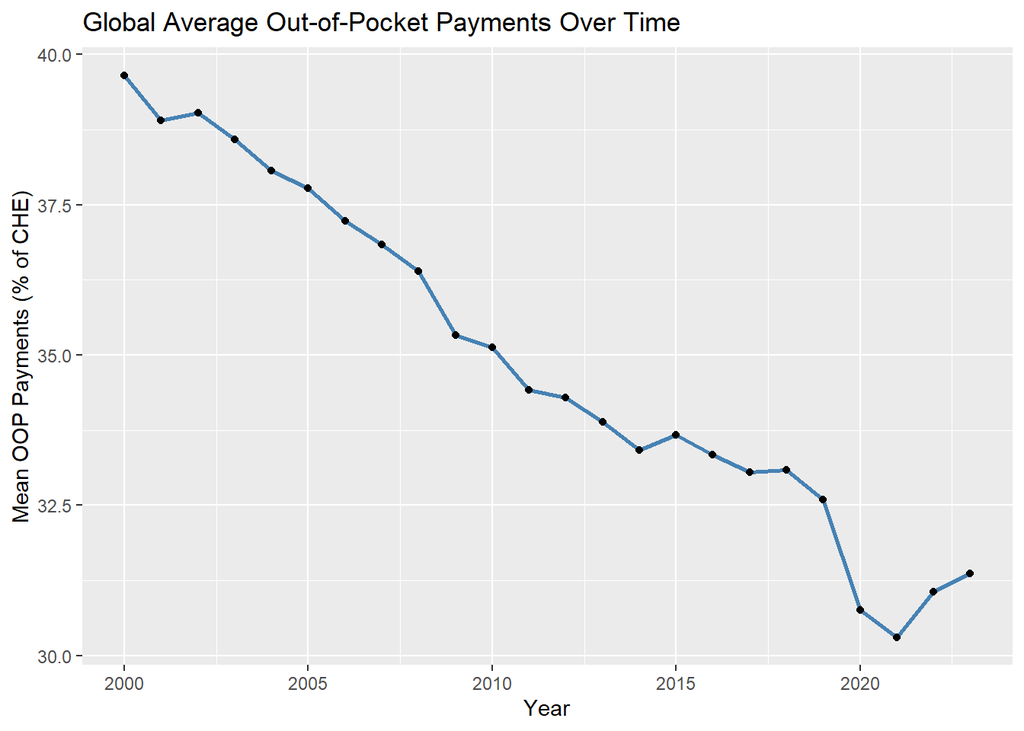

```r
model_data %>%
  group_by(year) %>%
  summarise(mean_oop = mean(oop_pct, na.rm = TRUE)) %>%
  ggplot(aes(x = year, y = mean_oop)) +
  geom_line(color = "steelblue", linewidth = 1) +
  geom_point() +
  labs(
    title = "Global Average Out-of-Pocket Payments Over Time",
    x = "Year",
    y = "Mean OOP Payments (% of CHE)"
  )
```

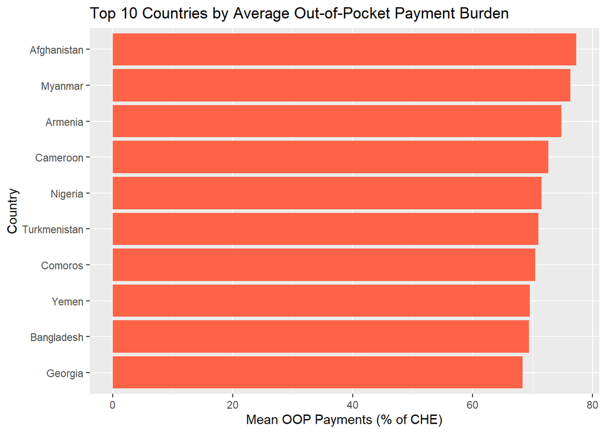

```r
# Top 10 countries with highest average OOP burden
model_data %>%
  group_by(country_name) %>%
  summarise(mean_oop = mean(oop_pct, na.rm = TRUE)) %>%
  slice_max(mean_oop, n = 10) %>%
  ggplot(aes(x = reorder(country_name, mean_oop), y = mean_oop)) +
  geom_col(fill = "tomato") +
  coord_flip() +
  labs(
    title = "Top 10 Countries by Average Out-of-Pocket Payment Burden",
    x = "Country",
    y = "Mean OOP Payments (% of CHE)"
  )
```

## Data Splitting

```r
# Set seed for reproducibility
set.seed(123)

data_split <- initial_split(model_data, prop = 0.75)
train_data <- training(data_split)
test_data  <- testing(data_split)

cat("Training set size:", nrow(train_data), "\n")
```

```
Training set size: 3020
```

```r
cat("Test set size:", nrow(test_data), "\n")
```

```
Test set size: 1007
```

```r
folds <- vfold_cv(train_data, v = 5, repeats = 1)

# Define a recipe for preprocessing
# We center and scale all predictors since LASSO needs this
oop_recipe <- recipe(oop_pct ~ govt_pct + private_pct + external_pct + year,
                     data = train_data) %>%
  step_normalize(all_predictors())

cat("Recipe and folds ready. Moving on to model fitting.\n")
```

```
Recipe and folds ready. Moving on to model fitting.
```

## Model Fitting

### Model 1: Linear Regression

```r
# Linear regression model spec
lm_spec <- linear_reg() %>%
  set_engine("lm")

# Workflow
lm_wf <- workflow() %>%
  add_recipe(oop_recipe) %>%
  add_model(lm_spec)

# Cross validation
lm_cv <- fit_resamples(
  lm_wf,
  resamples = folds,
  metrics = metric_set(rmse, rsq)
)

# CV metrics
lm_metrics <- collect_metrics(lm_cv)
print(lm_metrics)
```

```
# A tibble: 2 × 6
  .metric .estimator  mean     n std_err .config
  <chr>   <chr>      <dbl> <int>   <dbl> <chr>
1 rmse    standard   7.59      5 0.202   pre0_mod0_post0
2 rsq     standard   0.854     5 0.00758 pre0_mod0_post0
```

Linear regression was fit using the tidymodels framework (Kuhn & Wickham, 2020).

### Model 2: LASSO Regression

```r
# LASSO spec with penalty tuning
lasso_spec <- linear_reg(penalty = tune(), mixture = 1) %>%
  set_engine("glmnet")

# Workflow
lasso_wf <- workflow() %>%
  add_recipe(oop_recipe) %>%
  add_model(lasso_spec)

# Set up tuning grid
lasso_grid <- grid_regular(penalty(range = c(-4, 1)), levels = 30)

# Tune the penalty
lasso_tune <- tune_grid(
  lasso_wf,
  resamples = folds,
  grid = lasso_grid,
  metrics = metric_set(rmse, rsq)
)

# LASSO penalty
lasso_best <- select_best(lasso_tune, metric = "rmse")
print(lasso_best)
```

```
# A tibble: 1 × 2
  penalty .config
    <dbl> <chr>
1  0.0001 pre0_mod01_post0
```

```r
# Best metrics
lasso_metrics <- collect_metrics(lasso_tune) %>%
  filter(.config == lasso_best$.config)
print(lasso_metrics)
```

```
# A tibble: 2 × 7
  penalty .metric .estimator  mean     n std_err .config
    <dbl> <chr>   <chr>      <dbl> <int>   <dbl> <chr>
1  0.0001 rmse    standard   7.60      5 0.203   pre0_mod01_post0
2  0.0001 rsq     standard   0.854     5 0.00760 pre0_mod01_post0
```

LASSO regression was implemented using the glmnet engine within tidymodels (Kuhn & Wickham, 2020).

### Model 3: Random Forest

```r
# Random Forest
rf_spec <- rand_forest(mtry = tune(), trees = 500) %>%
  set_engine("ranger", importance = "impurity") %>%
  set_mode("regression")

# Workflow
rf_wf <- workflow() %>%
  add_recipe(oop_recipe) %>%
  add_model(rf_spec)

# Tuning grid
rf_grid <- grid_regular(mtry(range = c(1, 4)), levels = 4)

# Tune
rf_tune <- tune_grid(
  rf_wf,
  resamples = folds,
  grid = rf_grid,
  metrics = metric_set(rmse, rsq)
)

# Best RF parameters
rf_best <- select_best(rf_tune, metric = "rmse")
print(rf_best)
```

```
# A tibble: 1 × 2
   mtry .config
  <int> <chr>
1     2 pre0_mod2_post0
```

```r
# Collect best metrics
rf_metrics <- collect_metrics(rf_tune) %>%
  filter(.config == rf_best$.config)
print(rf_metrics)
```

```
# A tibble: 2 × 7
   mtry .metric .estimator  mean     n std_err .config
  <int> <chr>   <chr>      <dbl> <int>   <dbl> <chr>
1     2 rmse    standard   6.43      5 0.134   pre0_mod2_post0
2     2 rsq     standard   0.896     5 0.00455 pre0_mod2_post0
```

Random forest was implemented using the ranger engine (Wright & Ziegler, 2017) within the tidymodels framework (Kuhn & Wickham, 2020).

## Model Comparison and Selection

```r
# Model comparison
model_comparison <- tibble(
  model = c("Linear Regression", "LASSO", "Random Forest"),
  rmse  = c(
    lm_metrics %>% filter(.metric == "rmse") %>% pull(mean),
    lasso_metrics %>% filter(.metric == "rmse") %>% pull(mean),
    rf_metrics %>% filter(.metric == "rmse") %>% pull(mean)
  ),
  rsq = c(
    lm_metrics %>% filter(.metric == "rsq") %>% pull(mean),
    lasso_metrics %>% filter(.metric == "rsq") %>% pull(mean),
    rf_metrics %>% filter(.metric == "rsq") %>% pull(mean)
  )
)

print(model_comparison)
```

```
# A tibble: 3 × 3
  model              rmse   rsq
  <chr>             <dbl> <dbl>
1 Linear Regression  7.59 0.854
2 LASSO              7.60 0.854
3 Random Forest      6.43 0.896
```

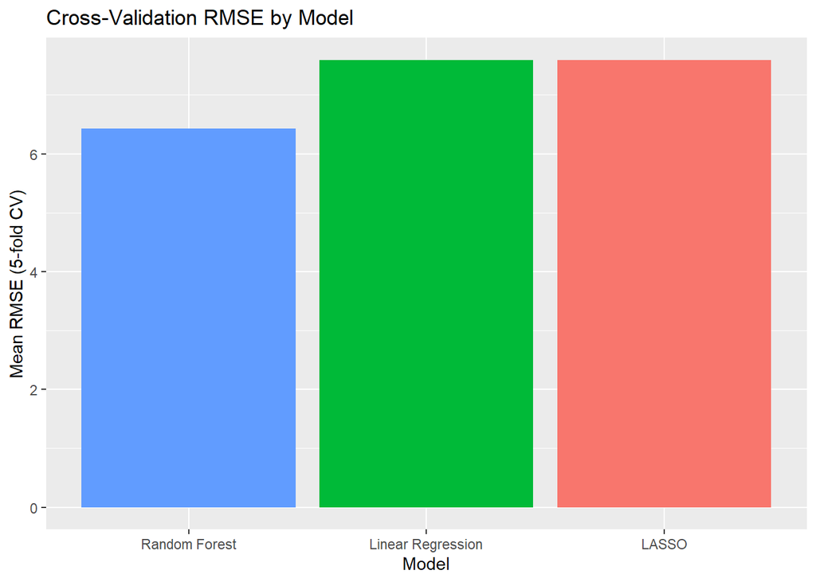

```r
# The comparison
model_comparison %>%
  ggplot(aes(x = reorder(model, rmse), y = rmse, fill = model)) +
  geom_col(show.legend = FALSE) +
  labs(
    title = "Cross-Validation RMSE by Model",
    x = "Model",
    y = "Mean RMSE (5-fold CV)"
  )
```

The random forest model performed the best, with the lowest RMSE and highest R² out of the three models. I selected it as the final model because it can capture more complex, non-linear relationships between different sources of health spending and out-of-pocket burden. This makes sense given how varied health financing systems are across countries with different income levels and structures. While linear regression is easier to interpret, the better predictive performance of the random forest makes it a stronger choice for this analysis.

## Final Model Evaluation on Test Data

```r
# Finalize the random forest workflow
rf_final_wf <- rf_wf %>%
  finalize_workflow(rf_best)

# Fit the final model
rf_final_fit <- last_fit(rf_final_wf, split = data_split)

# Collect test set metrics
rf_test_metrics <- collect_metrics(rf_final_fit)
print(rf_test_metrics)
```

```
# A tibble: 2 × 4
  .metric .estimator .estimate .config
  <chr>   <chr>          <dbl> <chr>
1 rmse    standard       6.08  pre0_mod0_post0
2 rsq     standard       0.912 pre0_mod0_post0
```

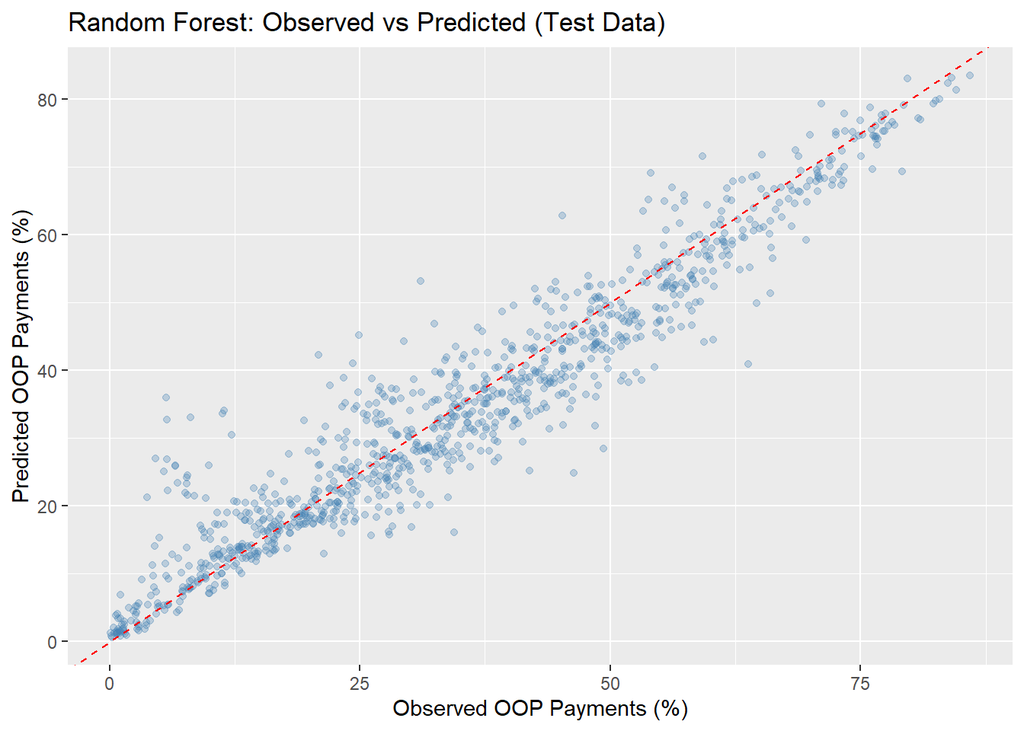

```r
# Get predictions
rf_test_preds <- collect_predictions(rf_final_fit)

# Plot observed vs predicted on test data
ggplot(rf_test_preds, aes(x = oop_pct, y = .pred)) +
  geom_point(alpha = 0.3, color = "steelblue") +
  geom_abline(slope = 1, intercept = 0, linetype = "dashed", color = "red") +
  labs(
    title = "Random Forest: Observed vs Predicted (Test Data)",
    x = "Observed OOP Payments (%)",
    y = "Predicted OOP Payments (%)"
  )
```

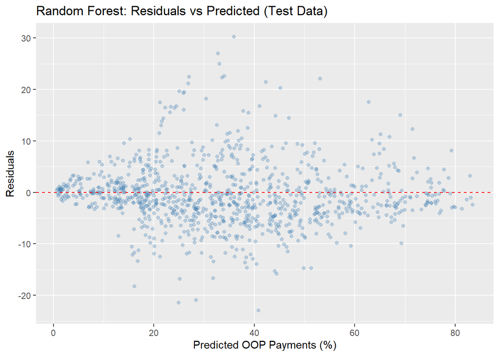

```r
# Residual plot
rf_test_preds %>%
  mutate(residual = .pred - oop_pct) %>%
  ggplot(aes(x = .pred, y = residual)) +
  geom_point(alpha = 0.3, color = "steelblue") +
  geom_hline(yintercept = 0, linetype = "dashed", color = "red") +
  labs(
    title = "Random Forest: Residuals vs Predicted (Test Data)",
    x = "Predicted OOP Payments (%)",
    y = "Residuals"
  )
```

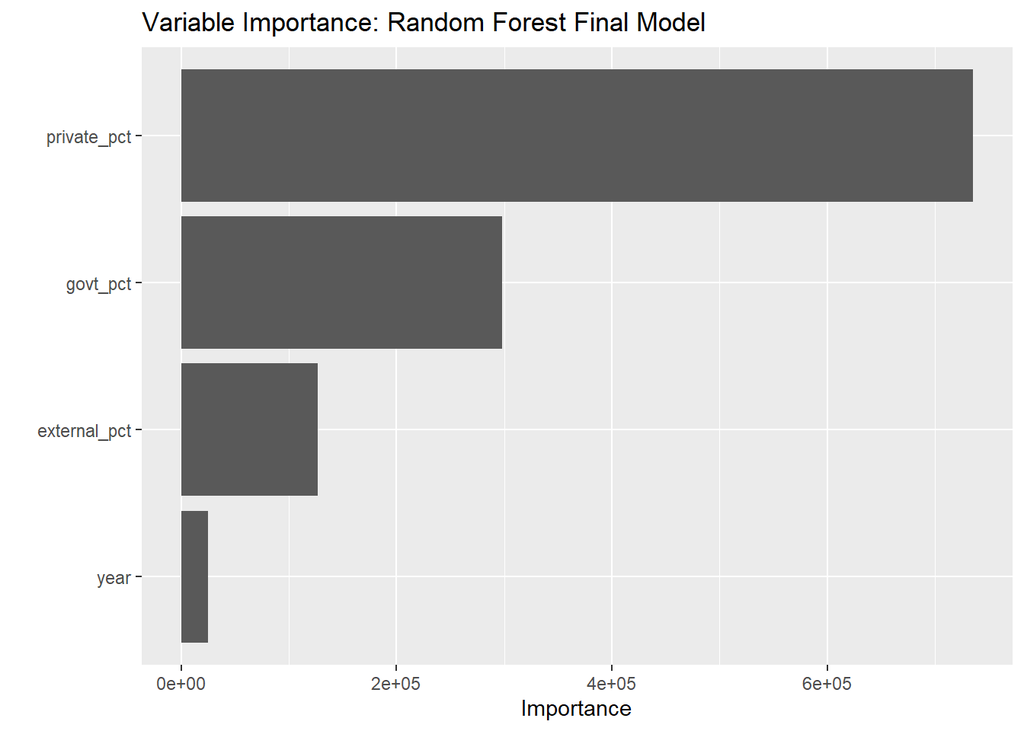

```r
# Variable importance
rf_final_fit %>%
  extract_fit_parsnip() %>%
  vip(num_features = 4) +
  labs(title = "Variable Importance: Random Forest Final Model")
```

## Discussion

This analysis used WHO global health spending data to examine whether a country’s out-of-pocket (OOP) payment burden can be predicted based on its mix of government, private, and external health spending.

The EDA showed a general decline in OOP burden globally from 2000 to 2023, reflecting progress toward universal health coverage. However, many countries in South and Southeast Asia and sub-Saharan Africa still have OOP burdens above 60% of total health spending, which remains a major concern.

One limitation is that this analysis treats each country-year as independent, even though repeated observations from the same country are likely correlated. A more rigorous approach would account for this clustering using mixed effects models.

## References

Data Science Learning Community. (2024). *Tidy Tuesday: A weekly social data project*. https://tidytues.day

Kuhn, M., & Wickham, H. (2020). *Tidymodels: A collection of packages for modeling and machine learning using tidyverse principles*. https://www.tidymodels.org

R Core Team. (2026). *R: A language and environment for statistical computing*. R Foundation for Statistical Computing. https://www.r-project.org/

Wickham, H., Averick, M., Bryan, J., Chang, W., McGowan, L., François, R., Grolemund, G., Hayes, A., Henry, L., Hester, J., Kuhn, M., Pedersen, T., Miller, E., Bache, S., Müller, K., Ooms, J., Robinson, D., Seidel, D., Spinu, V., … Yutani, H. (2019). Welcome to the tidyverse. *Journal of Open Source Software, 4*(43), 1686. https://doi.org/10.21105/joss.01686

World Health Organization. (2024). *Global Health Expenditure Database (GHED)*. WHO. https://apps.who.int/nha/database

Wright, M. N., & Ziegler, A. (2017). ranger: A fast implementation of random forests for high dimensional data in C++ and R. *Journal of Statistical Software, 77*(1), 1-17. https://doi.org/10.18637/jss.v077.i01